# Lids task - Markdown

Christoph Voelter

December 13, 2018

#### Notes

- Safari excluded (he completed only 5 trials in the transparent condition within 2 sessions)

## Choice performance

### Transparent vs opaque phase

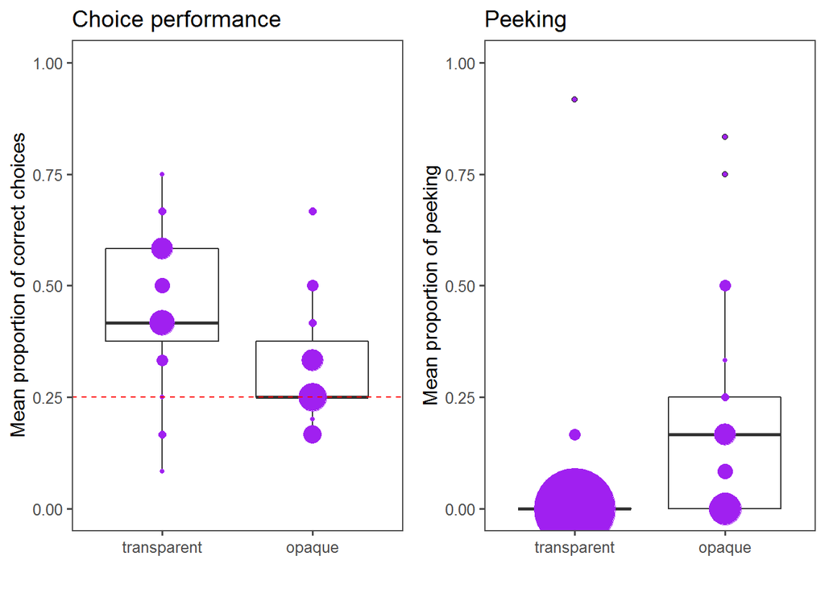

#### Comparison to chance

- DV: mean performance of correct choices.
- Chance value: 0.25

##### T-Test

- Transparent condition (pretest): Mean = 0.45, 95% CI [0.39, 0.51], *t*(26)=6.43, *p*=0
- Opaque condition (test): Mean = 0.32, 95% CI [0.27, 0.38], *t*(26)=2.63, *p*=0.014

### Transparent phase: trial types

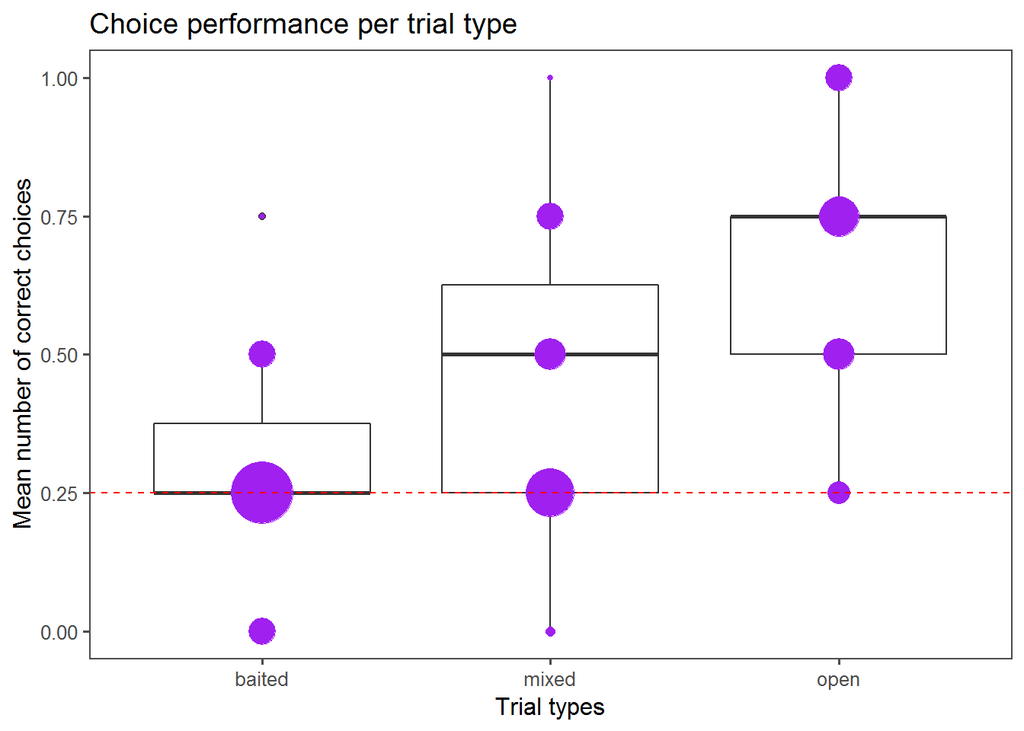

##### T-Test

- **All baited - one open** : Mean = 0.27, 95% CI [0.19, 0.35], *t*(26)=0.49, *p*=0.62619
- **Mixed condition** : Mean = 0.44, 95% CI [0.33, 0.54], *t*(26)=3.76, *p*=8.610^{-4}
- **All open - one baited** : Mean = 0.65, 95% CI [0.54, 0.75], *t*(26)=7.9, *p*=0

### Opaque phase: trial types

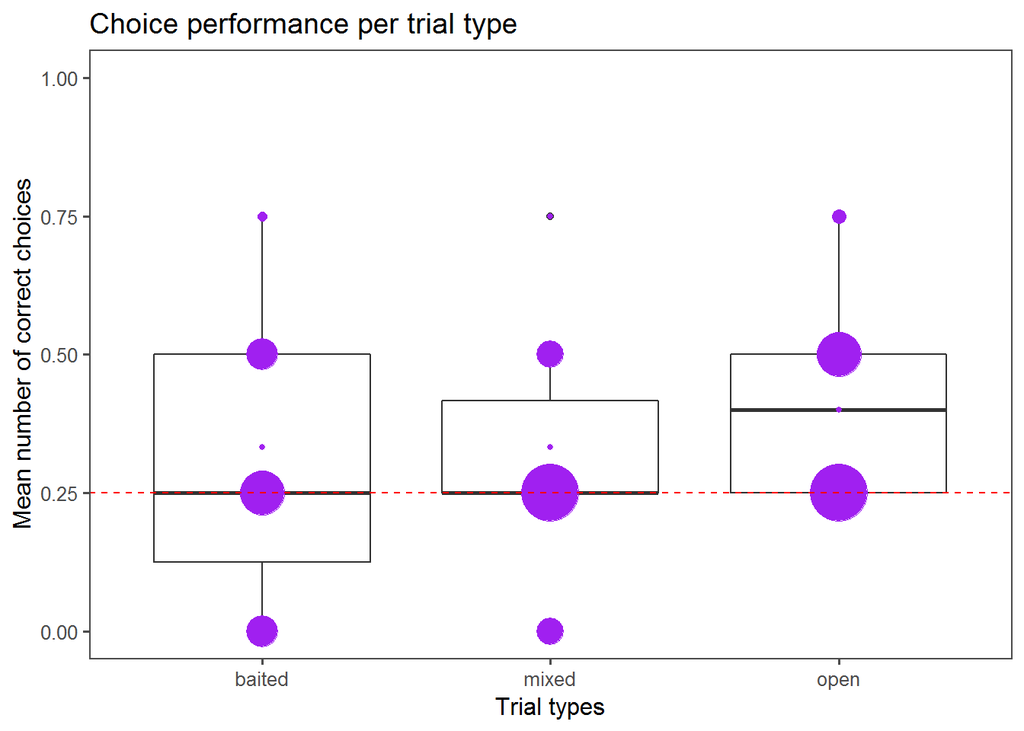

##### T-Test

- **All baited - one open** : Mean = 0.29, 95% CI [0.2, 0.38], *t*(26)=0.92, *p*=0.3666
- **Mixed condition** : Mean = 0.27, 95% CI [0.19, 0.35], *t*(26)=0.57, *p*=0.57086
- **All open - one baited** : Mean = 0.4, 95% CI [0.34, 0.47], *t*(26)=4.67, *p*=810^{-5}

## Peeking

### Comparison between transparent and opaque condition

##### T-Test

- Difference between peeking response between transparent and opaque condition: Mean difference = 0.13, 95% CI [0.06, 0.2], *t*(26)=3.66, *p*=0.001

##### Wilcoxon

- Difference between peeking response between transparent and opaque condition: T<sup>+</sup>=251, N=23, *p*=2.036094710^{-4}

### Peeking as function of trial types

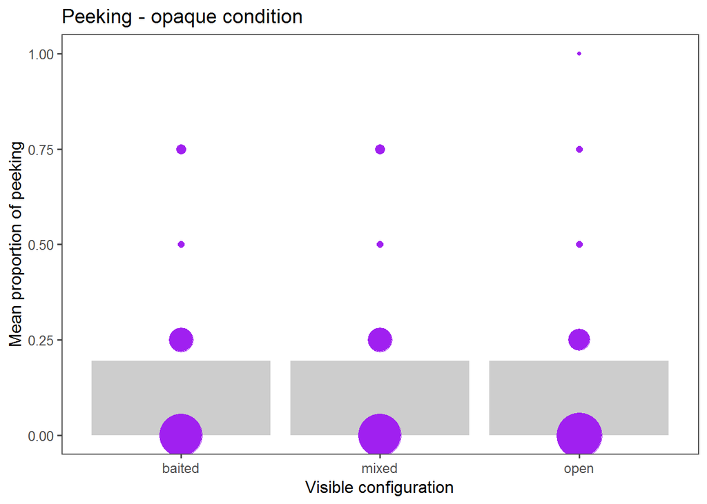

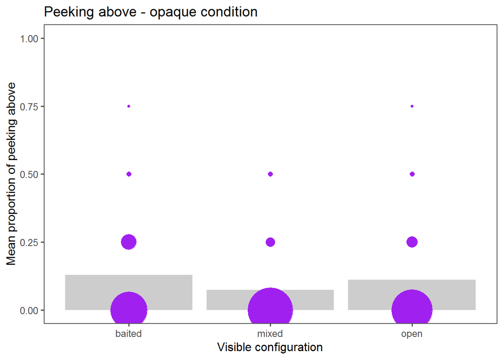

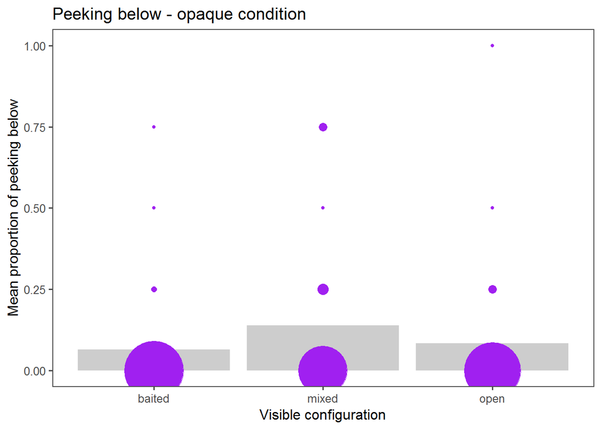

## Relationship between peeking and choice performance

### Opaque phase: peeking vs no peeking

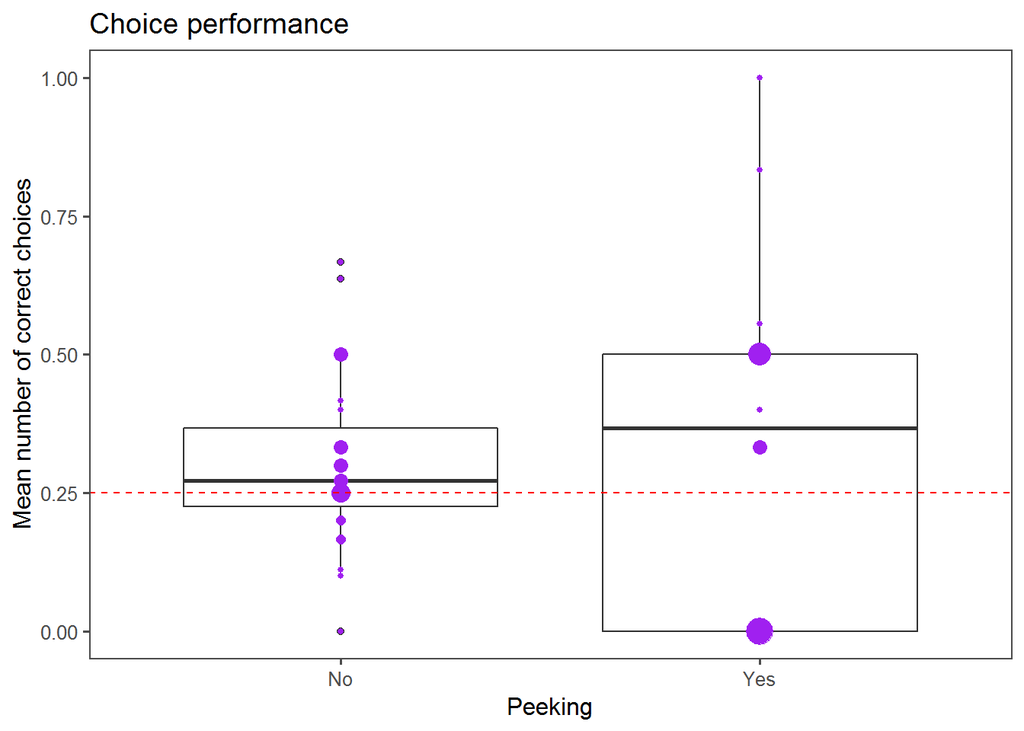

##### T-Test

- Opaque condition - **No peeking**: Mean = 0.31, 95% CI [0.25, 0.37], *t*(26)=1.9, *p*=0.069
- Opaque condition - **Peeking**: Mean = 0.35, 95% CI [0.2, 0.5], *t*(17)=1.4, *p*=0.18

##### Wilcoxon

- Opaque condition - **No Peeking**: Median = 0.27, T<sup>+</sup>=174, N=24, *p*=0.446
- Opaque condition - **Peeking**: Median = 0.37, T<sup>+</sup>=46, N=13, *p*=0.991

#### Only individuals who peek (at least once)

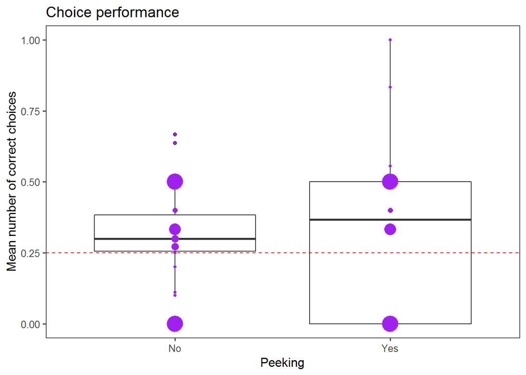

##### T-Test

- Opaque condition - **No peeking**: Mean = 0.32, 95% CI [0.23, 0.41], *t*(17)=1.69, *p*=0.109
- Opaque condition - **Peeking**: Mean = 0.35, 95% CI [0.2, 0.5], *t*(17)=1.4, *p*=0.18

##### Wilcoxon

- Opaque condition - **No Peeking**: Median = 0.3, T<sup>+</sup>=80.5, N=16, *p*=0.254
- Opaque condition - **Peeking**: Median = 0.37, T<sup>+</sup>=46, N=13, *p*=0.991